# Evaluating Winner’s Curse methods

### 3. Evaluating methods using a significance threshold of $5 \times 10^{-4}$

Similar to part 2 above, we use the code detailed in `norm_5e-4_10sim.R` with a total of 10 simulations in order to evaluate six different Winner’s Curse methods across each of the 24 scenarios. The same three bias evaluation metrics are considered.

Summary of results contained in `norm_5e-4_flb_10sim.csv`:

| Scenario | n_samples | h2 | prop_effect | S | EB | FIQT | BR | cl1 | cl2 | cl3 |
| --- | --- | --- | --- | --- | --- | --- | --- | --- | --- | --- |
| 1 | 30,000 | 0.3 | 0.010 | -1 | 0.9454 | 0.9449 | 0.9724 | 0.9695 | 0.9908 | 0.9810 |
| 2 | 300,000 | 0.3 | 0.010 | -1 | 0.5998 | 0.4608 | 0.5225 | 0.6079 | 0.6104 | 0.6041 |
| 3 | 30,000 | 0.8 | 0.010 | -1 | 0.7565 | 0.7121 | 0.7531 | 0.7961 | 0.8548 | 0.8243 |
| 4 | 300,000 | 0.8 | 0.010 | -1 | 0.5487 | 0.3505 | 0.4950 | 0.5632 | 0.5541 | 0.5527 |
| 5 | 30,000 | 0.3 | 0.001 | -1 | 0.7917 | 0.7348 | 0.7658 | 0.8377 | 0.8404 | 0.8363 |
| 6 | 300,000 | 0.3 | 0.001 | -1 | 0.6661 | 0.4972 | 0.6065 | 0.7068 | 0.6953 | 0.7118 |
| 7 | 30,000 | 0.8 | 0.001 | -1 | 0.7078 | 0.6059 | 0.6425 | 0.7589 | 0.7546 | 0.7597 |
| 8 | 300,000 | 0.8 | 0.001 | -1 | 0.6461 | 0.4438 | 0.6091 | 0.6983 | 0.6785 | 0.6876 |
| 9 | 30,000 | 0.3 | 0.010 | 0 | 0.9257 | 0.9170 | 0.9541 | 0.9556 | 0.9836 | 0.9656 |
| 10 | 300,000 | 0.3 | 0.010 | 0 | 0.5921 | 0.4611 | 0.5253 | 0.6127 | 0.6076 | 0.6077 |
| 11 | 30,000 | 0.8 | 0.010 | 0 | 0.7472 | 0.6949 | 0.7264 | 0.7870 | 0.8369 | 0.8084 |
| 12 | 300,000 | 0.8 | 0.010 | 0 | 0.5487 | 0.3547 | 0.5040 | 0.5672 | 0.5561 | 0.5614 |
| 13 | 30,000 | 0.3 | 0.001 | 0 | 0.7988 | 0.7340 | 0.7680 | 0.8391 | 0.8475 | 0.8430 |
| 14 | 300,000 | 0.3 | 0.001 | 0 | 0.6666 | 0.5070 | 0.6019 | 0.7161 | 0.6998 | 0.7102 |
| 15 | 30,000 | 0.8 | 0.001 | 0 | 0.7119 | 0.6147 | 0.6526 | 0.7682 | 0.7640 | 0.7697 |
| 16 | 300,000 | 0.8 | 0.001 | 0 | 0.6521 | 0.4562 | 0.6156 | 0.6935 | 0.6720 | 0.6790 |
| 17 | 30,000 | 0.3 | 0.010 | 1 | 0.8997 | 0.8978 | 0.9285 | 0.9448 | 0.9684 | 0.9548 |
| 18 | 300,000 | 0.3 | 0.010 | 1 | 0.5944 | 0.4521 | 0.5166 | 0.6140 | 0.6135 | 0.6090 |
| 19 | 30,000 | 0.8 | 0.010 | 1 | 0.7288 | 0.6709 | 0.7072 | 0.7641 | 0.8077 | 0.7797 |
| 20 | 300,000 | 0.8 | 0.010 | 1 | 0.5524 | 0.3568 | 0.5041 | 0.5718 | 0.5594 | 0.5648 |
| 21 | 30,000 | 0.3 | 0.001 | 1 | 0.7987 | 0.7440 | 0.7694 | 0.8492 | 0.8467 | 0.8481 |
| 22 | 300,000 | 0.3 | 0.001 | 1 | 0.6791 | 0.5203 | 0.6215 | 0.7270 | 0.7234 | 0.7250 |
| 23 | 30,000 | 0.8 | 0.001 | 1 | 0.7313 | 0.6308 | 0.6758 | 0.7742 | 0.7757 | 0.7785 |
| 24 | 300,000 | 0.8 | 0.001 | 1 | 0.6465 | 0.4756 | 0.6204 | 0.7071 | 0.6843 | 0.7013 |

$~$ $~$ $~$ $~$

**Fraction of significant SNPs** *less* **biased due to method implementation, using a significance threshold of $5 \times 10^{-4}$:**

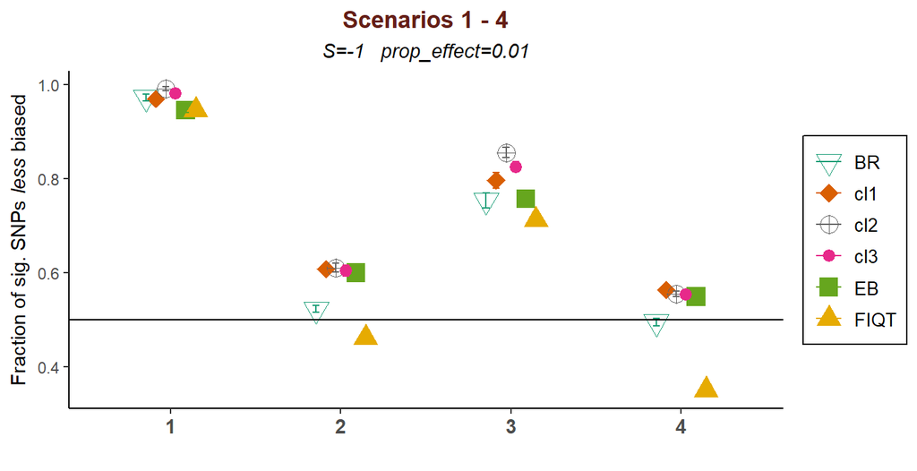

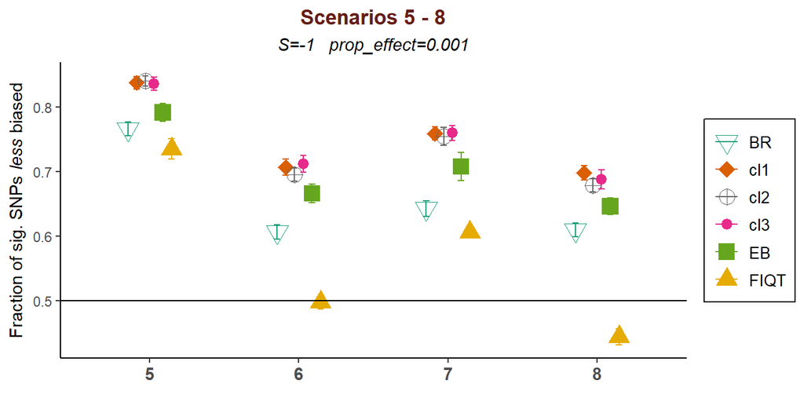

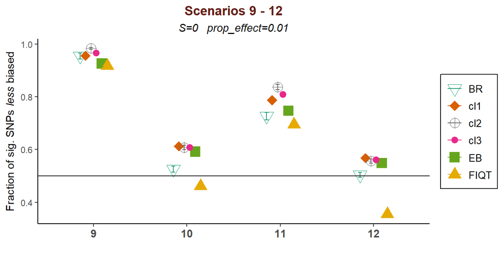

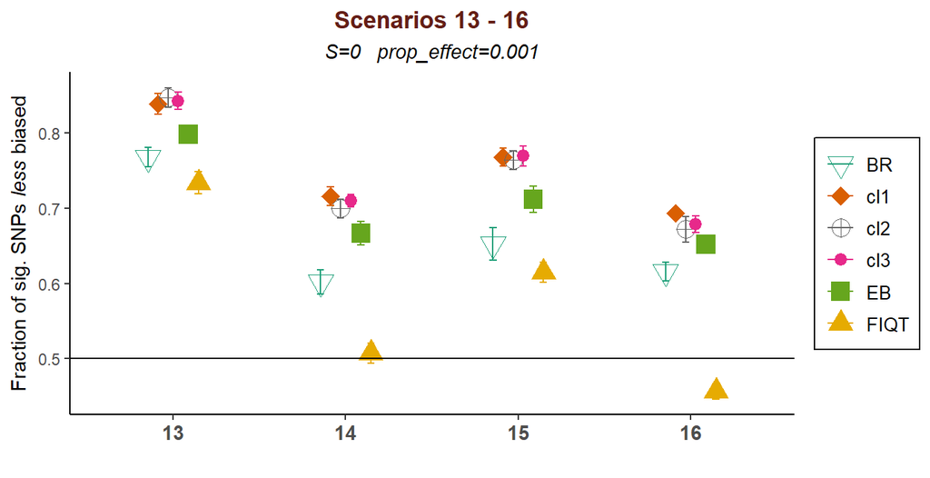

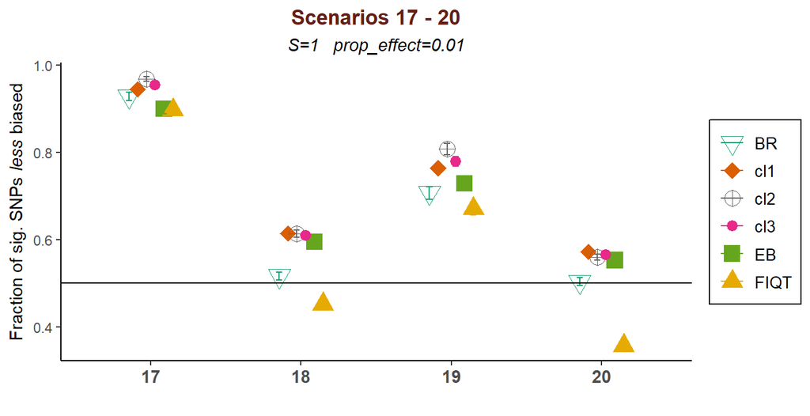

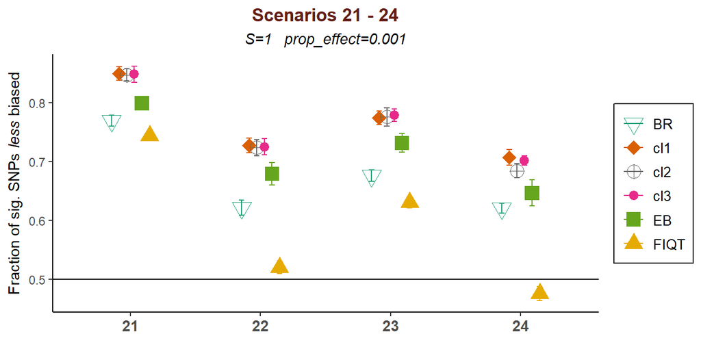

$~$ $~$ $~$ $~$

Summary of results contained in `norm_5e-4_mse-change2_10sim.csv`:

| Scenario | n_samples | h2 | prop_effect | S | EB | FIQT | BR | cl1 | cl2 | cl3 |
| --- | --- | --- | --- | --- | --- | --- | --- | --- | --- | --- |
| 1 | 30,000 | 0.3 | 0.010 | -1 | -0.001804 | -0.001801 | -0.001738 | -0.001627 | -0.001359 | -0.001496 |
| 2 | 300,000 | 0.3 | 0.010 | -1 | -0.000020 | -0.000011 | -0.000015 | -0.000012 | -0.000018 | -0.000016 |
| 3 | 30,000 | 0.8 | 0.010 | -1 | -0.000897 | -0.000889 | -0.000896 | -0.000799 | -0.000779 | -0.000826 |
| 4 | 300,000 | 0.8 | 0.010 | -1 | -0.000010 | -0.000001 | -0.000006 | -0.000004 | -0.000007 | -0.000007 |
| 5 | 30,000 | 0.3 | 0.001 | -1 | -0.001187 | -0.001180 | -0.001078 | -0.001162 | -0.000976 | -0.001079 |
| 6 | 300,000 | 0.3 | 0.001 | -1 | -0.000077 | -0.000069 | -0.000057 | -0.000071 | -0.000062 | -0.000068 |
| 7 | 30,000 | 0.8 | 0.001 | -1 | -0.000895 | -0.000824 | -0.000722 | -0.000876 | -0.000762 | -0.000846 |
| 8 | 300,000 | 0.8 | 0.001 | -1 | -0.000066 | -0.000065 | -0.000054 | -0.000068 | -0.000047 | -0.000060 |
| 9 | 30,000 | 0.3 | 0.010 | 0 | -0.001741 | -0.001753 | -0.001602 | -0.001492 | -0.001276 | -0.001402 |
| 10 | 300,000 | 0.3 | 0.010 | 0 | -0.000023 | -0.000022 | -0.000021 | -0.000022 | -0.000023 | -0.000023 |
| 11 | 30,000 | 0.8 | 0.010 | 0 | -0.000849 | -0.000875 | -0.000815 | -0.000802 | -0.000736 | -0.000834 |
| 12 | 300,000 | 0.8 | 0.010 | 0 | -0.000013 | -0.000008 | -0.000010 | -0.000009 | -0.000012 | -0.000011 |
| 13 | 30,000 | 0.3 | 0.001 | 0 | -0.001291 | -0.001264 | -0.001195 | -0.001171 | -0.001000 | -0.001160 |
| 14 | 300,000 | 0.3 | 0.001 | 0 | -0.000078 | -0.000070 | -0.000057 | -0.000072 | -0.000065 | -0.000072 |
| 15 | 30,000 | 0.8 | 0.001 | 0 | -0.000979 | -0.000940 | -0.000847 | -0.000931 | -0.000786 | -0.000888 |
| 16 | 300,000 | 0.8 | 0.001 | 0 | -0.000065 | -0.000065 | -0.000054 | -0.000067 | -0.000043 | -0.000059 |
| 17 | 30,000 | 0.3 | 0.010 | 1 | -0.001656 | -0.001708 | -0.001548 | -0.001517 | -0.001213 | -0.001378 |
| 18 | 300,000 | 0.3 | 0.010 | 1 | -0.000024 | -0.000023 | -0.000022 | -0.000024 | -0.000024 | -0.000026 |
| 19 | 30,000 | 0.8 | 0.010 | 1 | -0.000828 | -0.000830 | -0.000795 | -0.000802 | -0.000677 | -0.000753 |
| 20 | 300,000 | 0.8 | 0.010 | 1 | -0.000014 | -0.000012 | -0.000012 | -0.000013 | -0.000014 | -0.000015 |
| 21 | 30,000 | 0.3 | 0.001 | 1 | -0.001351 | -0.001330 | -0.001184 | -0.001192 | -0.000998 | -0.001148 |
| 22 | 300,000 | 0.3 | 0.001 | 1 | -0.000083 | -0.000076 | -0.000063 | -0.000081 | -0.000067 | -0.000076 |
| 23 | 30,000 | 0.8 | 0.001 | 1 | -0.001087 | -0.001002 | -0.000889 | -0.001002 | -0.000821 | -0.000902 |
| 24 | 300,000 | 0.8 | 0.001 | 1 | -0.000072 | -0.000071 | -0.000057 | -0.000073 | -0.000041 | -0.000065 |

$~$ $~$ $~$ $~$

*Change* **in average MSE over all significant SNPs due to method implementation, using a significance threshold of $5 \times 10^{-4}$:**

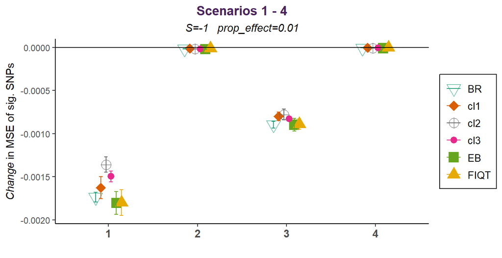

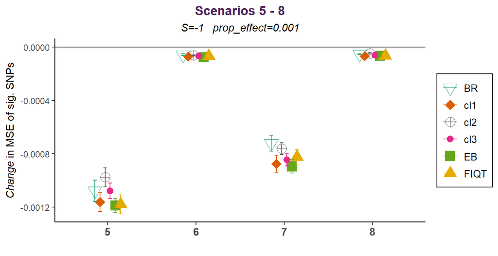

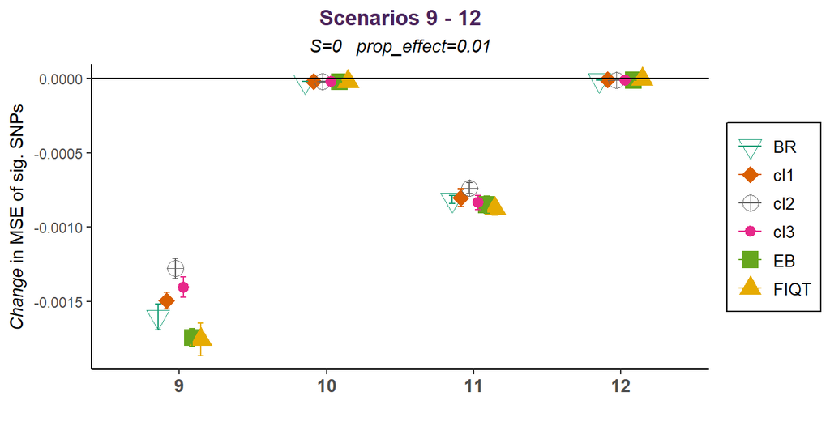

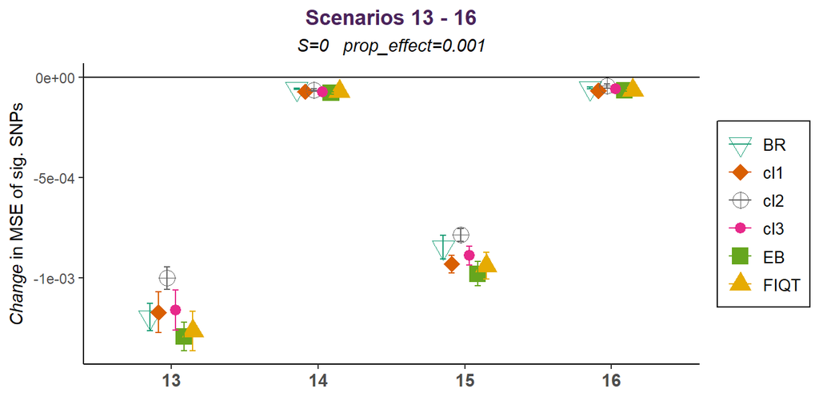

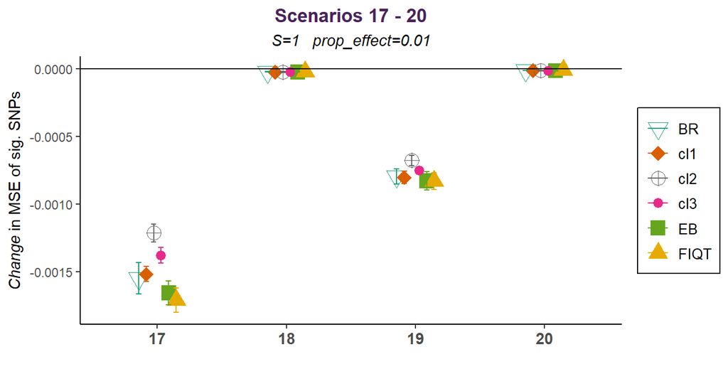

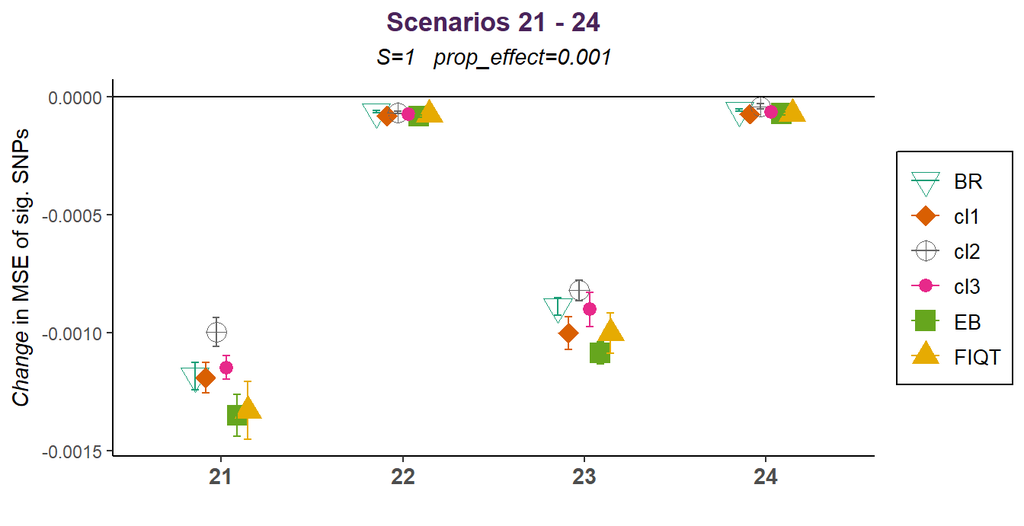

$~$ $~$ $~$ $~$

**TO DO:** Simulate the third bias evaluation metric for this significance threshold to obtain `norm_5e-4_mse-change_10sim.csv`. Plot in a similar manner to that above.

$~$ $~$ $~$ $~$

### 4. Skewed distribution of effect sizes

Here we investigate the 24 different scenarios under a skewed distribution of effect sizes. In order to create a bimodal distribution, we simulate 50% of effect sizes of the true effect SNPs from a normal distribution centered at 0 while the other half are generated from a normal distribution with mean 2.5. As above, we first have a look at the expected number of significant SNPs and the expected proportion of those in which their association estimate is exaggerated.

Running the code provided in `nsig_prop_bias_100sim.R`, we obtain the following results:

| Scenario | n_samples | h2 | prop_effect | S | n_sig 5e-8 | sd(n_sig) 5e-8 | prop_bias 5e-8 | sd(prop_bias) 5e-8 |
| --- | --- | --- | --- | --- | --- | --- | --- | --- |
| 1 | 30,000 | 0.3 | 0.010 | -1 | 0.70 | 0.916 | 0.5400 | 0.5009 |
| 2 | 300,000 | 0.3 | 0.010 | -1 | 851.27 | 18.889 | 0.7649 | 0.0130 |
| 3 | 30,000 | 0.8 | 0.010 | -1 | 27.10 | 5.361 | 0.9880 | 0.0211 |
| 4 | 300,000 | 0.8 | 0.010 | -1 | 2793.70 | 32.045 | 0.6260 | 0.0094 |
| 5 | 30,000 | 0.3 | 0.001 | -1 | 85.32 | 5.255 | 0.7610 | 0.0444 |
| 6 | 300,000 | 0.3 | 0.001 | -1 | 575.74 | 12.120 | 0.5517 | 0.0202 |
| 7 | 30,000 | 0.8 | 0.001 | -1 | 279.53 | 9.591 | 0.6264 | 0.0279 |
| 8 | 300,000 | 0.8 | 0.001 | -1 | 729.53 | 11.935 | 0.5272 | 0.0188 |
| 9 | 30,000 | 0.3 | 0.010 | 0 | 0.52 | 0.810 | 0.5200 | 0.5021 |
| 10 | 300,000 | 0.3 | 0.010 | 0 | 896.33 | 19.033 | 0.7538 | 0.0125 |
| 11 | 30,000 | 0.8 | 0.010 | 0 | 28.61 | 4.752 | 0.9917 | 0.0170 |
| 12 | 300,000 | 0.8 | 0.010 | 0 | 2764.21 | 29.531 | 0.6165 | 0.0084 |
| 13 | 30,000 | 0.3 | 0.001 | 0 | 90.29 | 6.253 | 0.7590 | 0.0473 |
| 14 | 300,000 | 0.3 | 0.001 | 0 | 546.47 | 11.184 | 0.5485 | 0.0224 |
| 15 | 30,000 | 0.8 | 0.001 | 0 | 276.46 | 10.923 | 0.6153 | 0.0303 |
| 16 | 300,000 | 0.8 | 0.001 | 0 | 702.71 | 12.246 | 0.5255 | 0.0171 |
| 17 | 30,000 | 0.3 | 0.010 | 1 | 0.65 | 0.744 | 0.3800 | 0.4878 |
| 18 | 300,000 | 0.3 | 0.010 | 1 | 913.62 | 19.852 | 0.7889 | 0.0122 |
| 19 | 30,000 | 0.8 | 0.010 | 1 | 20.87 | 4.341 | 0.9989 | 0.0080 |
| 20 | 300,000 | 0.8 | 0.010 | 1 | 2959.28 | 27.593 | 0.6104 | 0.0084 |
| 21 | 30,000 | 0.3 | 0.001 | 1 | 91.49 | 5.718 | 0.7817 | 0.0415 |
| 22 | 300,000 | 0.3 | 0.001 | 1 | 534.82 | 9.277 | 0.5417 | 0.0216 |
| 23 | 30,000 | 0.8 | 0.001 | 1 | 296.23 | 9.175 | 0.6126 | 0.0283 |
| 24 | 300,000 | 0.8 | 0.001 | 1 | 658.63 | 11.636 | 0.5258 | 0.0174 |

$~$ $~$ $~$ $~$

Next, we repeat the process illustrated in Section 2 using the same bias evaluation metrics with a significance threshold of $5 \times 10^{-8}$.

Summary of results contained in `skew_5e-8_flb_10sim.csv`:

| Scenario | n_samples | h2 | prop_effect | S | EB | FIQT | BR | cl1 | cl2 | cl3 |
| --- | --- | --- | --- | --- | --- | --- | --- | --- | --- | --- |
| 1 | 30,000 | 0.3 | 0.010 | -1 | 0.4000 | 0.4000 | 0.5000 | 0.3500 | 0.6000 | 0.4000 |
| 2 | 300,000 | 0.3 | 0.010 | -1 | 0.6551 | 0.4493 | 0.6239 | 0.5250 | 0.4993 | 0.5099 |
| 3 | 30,000 | 0.8 | 0.010 | -1 | 0.9219 | 0.8157 | 0.8430 | 0.5993 | 0.7826 | 0.6696 |
| 4 | 300,000 | 0.8 | 0.010 | -1 | 0.5642 | 0.2830 | 0.5399 | 0.5135 | 0.4877 | 0.4946 |
| 5 | 30,000 | 0.3 | 0.001 | -1 | 0.6407 | 0.3385 | 0.5081 | 0.5129 | 0.5228 | 0.5039 |
| 6 | 300,000 | 0.3 | 0.001 | -1 | 0.4893 | 0.1320 | 0.3733 | 0.5001 | 0.4867 | 0.5017 |
| 7 | 30,000 | 0.8 | 0.001 | -1 | 0.5348 | 0.2346 | 0.3760 | 0.5194 | 0.4815 | 0.4969 |
| 8 | 300,000 | 0.8 | 0.001 | -1 | 0.4728 | 0.0979 | 0.4023 | 0.5118 | 0.4724 | 0.4949 |
| 9 | 30,000 | 0.3 | 0.010 | 0 | 0.5000 | 0.2000 | 0.6500 | 0.5000 | 0.6000 | 0.2000 |
| 10 | 300,000 | 0.3 | 0.010 | 0 | 0.6371 | 0.4376 | 0.6127 | 0.5294 | 0.5011 | 0.5043 |
| 11 | 30,000 | 0.8 | 0.010 | 0 | 0.9168 | 0.7756 | 0.9011 | 0.6288 | 0.7657 | 0.6856 |
| 12 | 300,000 | 0.8 | 0.010 | 0 | 0.5576 | 0.2742 | 0.5339 | 0.5148 | 0.4895 | 0.4931 |
| 13 | 30,000 | 0.3 | 0.001 | 0 | 0.6110 | 0.3007 | 0.5274 | 0.5337 | 0.5013 | 0.5006 |
| 14 | 300,000 | 0.3 | 0.001 | 0 | 0.5028 | 0.1378 | 0.3798 | 0.5044 | 0.4790 | 0.4923 |
| 15 | 30,000 | 0.8 | 0.001 | 0 | 0.5269 | 0.2025 | 0.3654 | 0.5132 | 0.4802 | 0.5086 |
| 16 | 300,000 | 0.8 | 0.001 | 0 | 0.4787 | 0.1036 | 0.3968 | 0.5069 | 0.4732 | 0.4915 |
| 17 | 30,000 | 0.3 | 0.010 | 1 | 0.4000 | 0.3000 | 0.3000 | 0.4000 | 0.7000 | 0.2000 |
| 18 | 300,000 | 0.3 | 0.010 | 1 | 0.6663 | 0.4792 | 0.6488 | 0.5359 | 0.4966 | 0.5105 |
| 19 | 30,000 | 0.8 | 0.010 | 1 | 0.9172 | 0.8982 | 0.9400 | 0.7142 | 0.9132 | 0.7743 |
| 20 | 300,000 | 0.8 | 0.010 | 1 | 0.5511 | 0.2637 | 0.5385 | 0.5118 | 0.4811 | 0.4910 |
| 21 | 30,000 | 0.3 | 0.001 | 1 | 0.6622 | 0.3305 | 0.5850 | 0.5578 | 0.4967 | 0.5014 |
| 22 | 300,000 | 0.3 | 0.001 | 1 | 0.4956 | 0.1213 | 0.3791 | 0.5114 | 0.4672 | 0.5027 |
| 23 | 30,000 | 0.8 | 0.001 | 1 | 0.4926 | 0.1866 | 0.3482 | 0.5037 | 0.4856 | 0.4930 |
| 24 | 300,000 | 0.8 | 0.001 | 1 | 0.4799 | 0.0999 | 0.4081 | 0.5057 | 0.4682 | 0.4987 |

$~$ $~$ $~$ $~$

**Fraction of significant SNPs** *less* **biased due to method implementation, using a significance threshold of $5 \times 10^{-8}$ and a** *skewed* **distribution of effect sizes:**

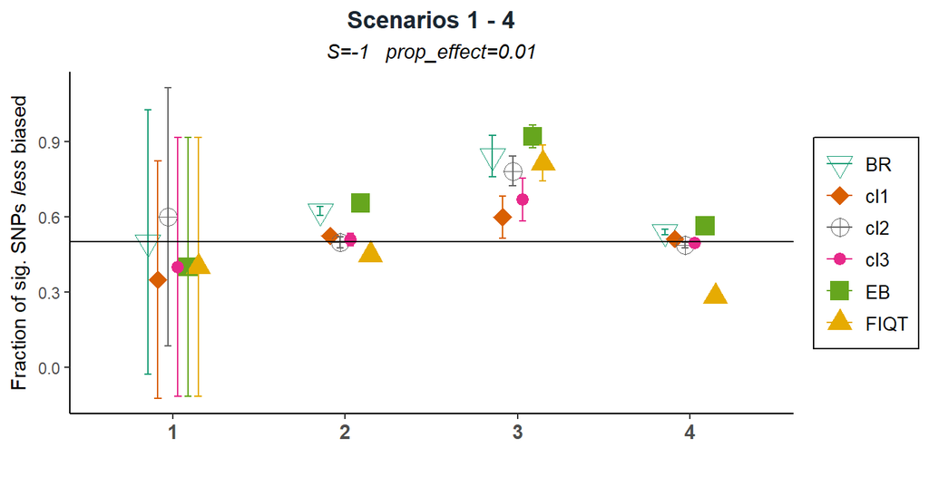

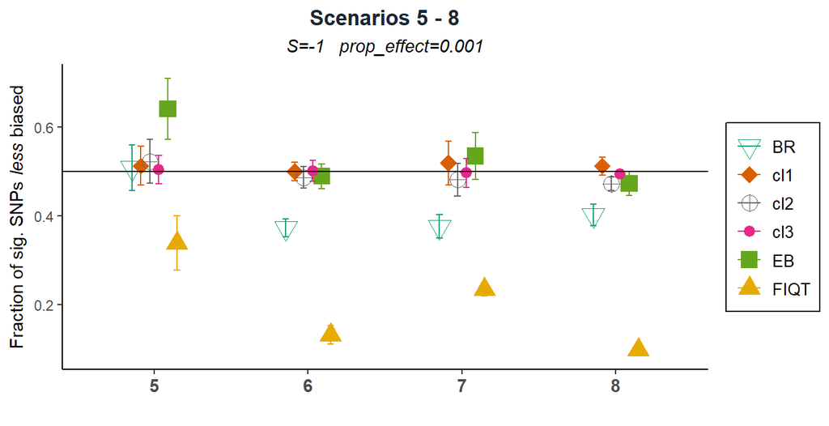

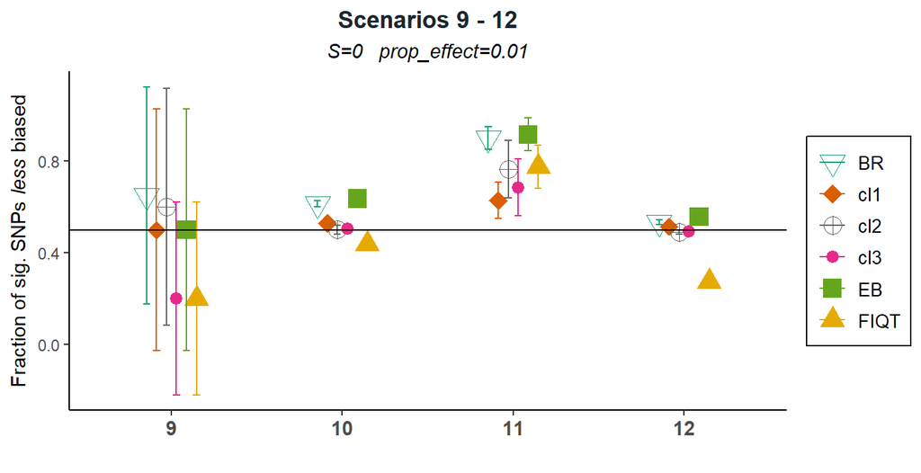

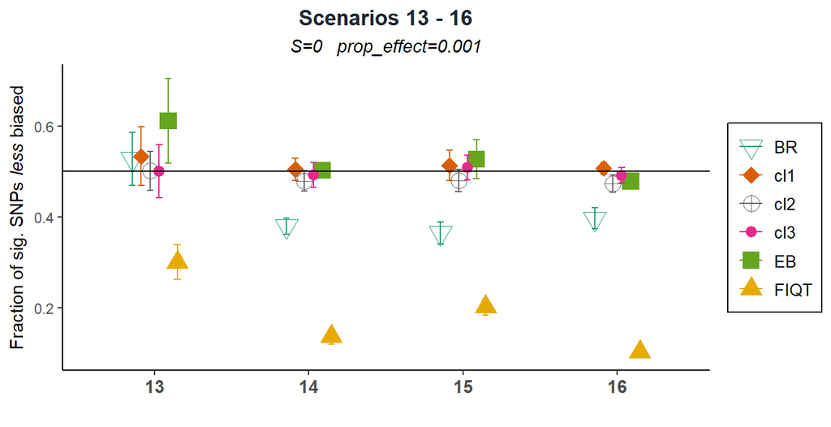

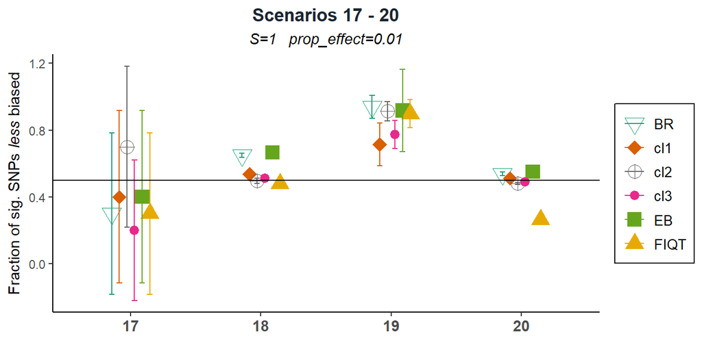

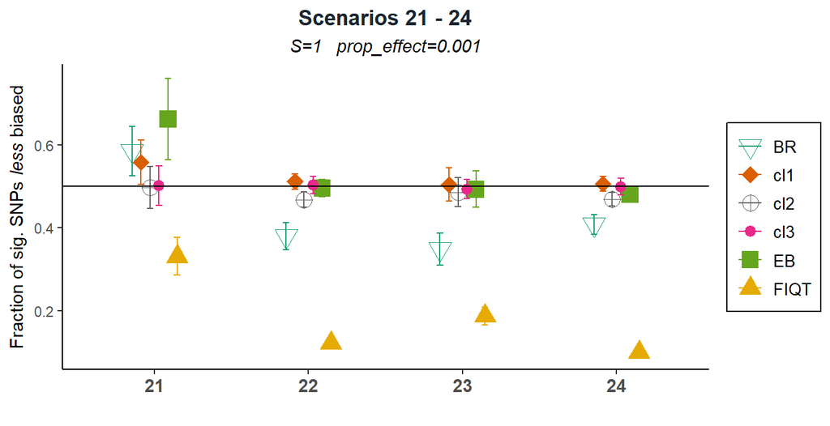

$~$ $~$ $~$ $~$